|

|

# Advanced Regression - House Price Prediction

|

| vamshi.krishna.prime@gmail.com | | Mobile: (+91) 9491392912 |

|

# Table of contents:

1. **Case Study Overview**
   - 1.1. Introduction
   - 1.2. Business Understanding
   - 1.3. Business Usecase
   - 1.4. Software requirements
   - 1.5. Business Objectives
1. **Explore Data**
   - 2.1. Load Data
   - 2.2. Data Dictionary
   - 2.3. Dataset Exploration

## 1. `Case Study Overview`

=================================

- 1.1. Introduction
- 1.2. Business Understanding
- 1.3. Business Usecase
- 1.4. Software requirements
- 1.5. Business Objectives

### [1](#1.-Case-Study-Overview).1 Introduction:

A US-based housing company named **Surprise Housing** has decided to enter the Australian market. The company uses data analytics to purchase houses at a price below their actual values and flip them on at a higher price.

### [1](#1.-Case-Study-Overview).2 Business Understanding:

The company is looking at prospective properties to buy to enter the market. The task is to build a regression model using regularisation in order to predict the actual value of the prospective properties and decide whether to invest in them or not.

### [1](#1.-Case-Study-Overview).3 Business Usecase:

The company wants to understand:

- Which variables are significant in predicting the price of a house, and
- How well those variables describe the price of a house.

Along with the above details, determine the optimal value of `lambda` for `ridge` and `lasso` regression.

### [1](#1.-Case-Study-Overview).4 Software requirements:

This case study uses `Python 3.10` version and is designed to be compatible with versions greater than '3.6'. It is highly recommended that you use the `Anaconda` distribution to install Python, since the distribution includes all necessary Python libraries as well as Jupyter Notebooks. The following libraries are expected to be used in this project:

- NumPy
- Pandas
- Matplotlib
- Seaborn
- Math
- Conda
- Git
- Jupyter Notebook

**NOTE:**

An environment.yaml file is provided to install all the necessary libraries in the environment to replicate the same work flow.

-------- End of section 1. Case Study Overview --------

## 2. `Data Exploration`

===========================

- 2.1. Load Libraries
- 2.2. Load Data
- 2.2. Data Dictionary
- 2.3. Dataset Exploration

### [2](#2.-Explore-Data).1 Load Libraries:

Load relevant libraries at this section to ease the maintainance and tracking.

```python
# import libraries
import numpy as np
import pandas as pd
import matplotlib.pyplot as plt
from matplotlib.lines import Line2D
import matplotlib.patches as patches
%matplotlib inline
import seaborn as sb
import traceback
import math
import datetime
import os

# suppress warnings from final output
import warnings
warnings.simplefilter("ignore")
```

### [2](#2.-Explore-Data).2 Load Data:

Import data for further analysis:

```python
# import data
try:
    df = pd.read_csv('train.csv', delimiter = ',')
    print('Data Load: Successful')
except Exception:
    traceback.print_exc()
    print('Data Load: Failure')
```

```
Data Load: Successful
```

### [2](#2.-Explore-Data).3 Understand Variables:

Check the shape of the excel file loaded as the dataframe:

```python
df.shape
```

```
(1460, 81)
```

```python
print(f'The data consists of {df.shape[0]} entries/rows and {df.shape[1]} columns.')
```

```
The data consists of 1460 entries/rows and 81 columns.
```

Visually inspect the data dictionary

- Diaplay the first 5 rows in the dataset:

```python
df.head()
```

|  | Id | MSSubClass | MSZoning | LotFrontage | LotArea | Street | Alley | LotShape | LandContour | Utilities | ... | PoolArea | PoolQC | Fence | MiscFeature | MiscVal | MoSold | YrSold | SaleType | SaleCondition | SalePrice |
| --- | --- | --- | --- | --- | --- | --- | --- | --- | --- | --- | --- | --- | --- | --- | --- | --- | --- | --- | --- | --- | --- |
| 0 | 1 | 60 | RL | 65.0 | 8450 | Pave | NaN | Reg | Lvl | AllPub | ... | 0 | NaN | NaN | NaN | 0 | 2 | 2008 | WD | Normal | 208500 |
| 1 | 2 | 20 | RL | 80.0 | 9600 | Pave | NaN | Reg | Lvl | AllPub | ... | 0 | NaN | NaN | NaN | 0 | 5 | 2007 | WD | Normal | 181500 |
| 2 | 3 | 60 | RL | 68.0 | 11250 | Pave | NaN | IR1 | Lvl | AllPub | ... | 0 | NaN | NaN | NaN | 0 | 9 | 2008 | WD | Normal | 223500 |
| 3 | 4 | 70 | RL | 60.0 | 9550 | Pave | NaN | IR1 | Lvl | AllPub | ... | 0 | NaN | NaN | NaN | 0 | 2 | 2006 | WD | Abnorml | 140000 |
| 4 | 5 | 60 | RL | 84.0 | 14260 | Pave | NaN | IR1 | Lvl | AllPub | ... | 0 | NaN | NaN | NaN | 0 | 12 | 2008 | WD | Normal | 250000 |

5 rows × 81 columns

- Display the bottom 5 rows in the dataset:

```python
df.tail()
```

|  | Id | MSSubClass | MSZoning | LotFrontage | LotArea | Street | Alley | LotShape | LandContour | Utilities | ... | PoolArea | PoolQC | Fence | MiscFeature | MiscVal | MoSold | YrSold | SaleType | SaleCondition | SalePrice |
| --- | --- | --- | --- | --- | --- | --- | --- | --- | --- | --- | --- | --- | --- | --- | --- | --- | --- | --- | --- | --- | --- |
| 1455 | 1456 | 60 | RL | 62.0 | 7917 | Pave | NaN | Reg | Lvl | AllPub | ... | 0 | NaN | NaN | NaN | 0 | 8 | 2007 | WD | Normal | 175000 |
| 1456 | 1457 | 20 | RL | 85.0 | 13175 | Pave | NaN | Reg | Lvl | AllPub | ... | 0 | NaN | MnPrv | NaN | 0 | 2 | 2010 | WD | Normal | 210000 |
| 1457 | 1458 | 70 | RL | 66.0 | 9042 | Pave | NaN | Reg | Lvl | AllPub | ... | 0 | NaN | GdPrv | Shed | 2500 | 5 | 2010 | WD | Normal | 266500 |
| 1458 | 1459 | 20 | RL | 68.0 | 9717 | Pave | NaN | Reg | Lvl | AllPub | ... | 0 | NaN | NaN | NaN | 0 | 4 | 2010 | WD | Normal | 142125 |
| 1459 | 1460 | 20 | RL | 75.0 | 9937 | Pave | NaN | Reg | Lvl | AllPub | ... | 0 | NaN | NaN | NaN | 0 | 6 | 2008 | WD | Normal | 147500 |

5 rows × 81 columns

- List the columns in the data.

```python
df.columns
```

```
Index(['Id', 'MSSubClass', 'MSZoning', 'LotFrontage', 'LotArea', 'Street',
       'Alley', 'LotShape', 'LandContour', 'Utilities', 'LotConfig',
       'LandSlope', 'Neighborhood', 'Condition1', 'Condition2', 'BldgType',
       'HouseStyle', 'OverallQual', 'OverallCond', 'YearBuilt', 'YearRemodAdd',
       'RoofStyle', 'RoofMatl', 'Exterior1st', 'Exterior2nd', 'MasVnrType',
       'MasVnrArea', 'ExterQual', 'ExterCond', 'Foundation', 'BsmtQual',
       'BsmtCond', 'BsmtExposure', 'BsmtFinType1', 'BsmtFinSF1',
       'BsmtFinType2', 'BsmtFinSF2', 'BsmtUnfSF', 'TotalBsmtSF', 'Heating',
       'HeatingQC', 'CentralAir', 'Electrical', '1stFlrSF', '2ndFlrSF',
       'LowQualFinSF', 'GrLivArea', 'BsmtFullBath', 'BsmtHalfBath', 'FullBath',
       'HalfBath', 'BedroomAbvGr', 'KitchenAbvGr', 'KitchenQual',
       'TotRmsAbvGrd', 'Functional', 'Fireplaces', 'FireplaceQu', 'GarageType',
       'GarageYrBlt', 'GarageFinish', 'GarageCars', 'GarageArea', 'GarageQual',
       'GarageCond', 'PavedDrive', 'WoodDeckSF', 'OpenPorchSF',
       'EnclosedPorch', '3SsnPorch', 'ScreenPorch', 'PoolArea', 'PoolQC',
       'Fence', 'MiscFeature', 'MiscVal', 'MoSold', 'YrSold', 'SaleType',
       'SaleCondition', 'SalePrice'],
      dtype='object')
```

### [2](#2.-Explore-Data).3 Understand Dataset:

```python
df.info()
```

```
<class 'pandas.core.frame.DataFrame'>
RangeIndex: 1460 entries, 0 to 1459
Data columns (total 81 columns):
 #   Column         Non-Null Count  Dtype
---  ------         --------------  -----
 0   Id             1460 non-null   int64
 1   MSSubClass     1460 non-null   int64
 2   MSZoning       1460 non-null   object
 3   LotFrontage    1201 non-null   float64
 4   LotArea        1460 non-null   int64
 5   Street         1460 non-null   object
 6   Alley          91 non-null     object
 7   LotShape       1460 non-null   object
 8   LandContour    1460 non-null   object
 9   Utilities      1460 non-null   object
```

[output cut: 73 more lines]

```python
df.describe()
```

|  | Id | MSSubClass | LotFrontage | LotArea | OverallQual | OverallCond | YearBuilt | YearRemodAdd | MasVnrArea | BsmtFinSF1 | ... | WoodDeckSF | OpenPorchSF | EnclosedPorch | 3SsnPorch | ScreenPorch | PoolArea | MiscVal | MoSold | YrSold | SalePrice |
| --- | --- | --- | --- | --- | --- | --- | --- | --- | --- | --- | --- | --- | --- | --- | --- | --- | --- | --- | --- | --- | --- |
| count | 1460.000000 | 1460.000000 | 1201.000000 | 1460.000000 | 1460.000000 | 1460.000000 | 1460.000000 | 1460.000000 | 1452.000000 | 1460.000000 | ... | 1460.000000 | 1460.000000 | 1460.000000 | 1460.000000 | 1460.000000 | 1460.000000 | 1460.000000 | 1460.000000 | 1460.000000 | 1460.000000 |
| mean | 730.500000 | 56.897260 | 70.049958 | 10516.828082 | 6.099315 | 5.575342 | 1971.267808 | 1984.865753 | 103.685262 | 443.639726 | ... | 94.244521 | 46.660274 | 21.954110 | 3.409589 | 15.060959 | 2.758904 | 43.489041 | 6.321918 | 2007.815753 | 180921.195890 |
| std | 421.610009 | 42.300571 | 24.284752 | 9981.264932 | 1.382997 | 1.112799 | 30.202904 | 20.645407 | 181.066207 | 456.098091 | ... | 125.338794 | 66.256028 | 61.119149 | 29.317331 | 55.757415 | 40.177307 | 496.123024 | 2.703626 | 1.328095 | 79442.502883 |
| min | 1.000000 | 20.000000 | 21.000000 | 1300.000000 | 1.000000 | 1.000000 | 1872.000000 | 1950.000000 | 0.000000 | 0.000000 | ... | 0.000000 | 0.000000 | 0.000000 | 0.000000 | 0.000000 | 0.000000 | 0.000000 | 1.000000 | 2006.000000 | 34900.000000 |
| 25% | 365.750000 | 20.000000 | 59.000000 | 7553.500000 | 5.000000 | 5.000000 | 1954.000000 | 1967.000000 | 0.000000 | 0.000000 | ... | 0.000000 | 0.000000 | 0.000000 | 0.000000 | 0.000000 | 0.000000 | 0.000000 | 5.000000 | 2007.000000 | 129975.000000 |
| 50% | 730.500000 | 50.000000 | 69.000000 | 9478.500000 | 6.000000 | 5.000000 | 1973.000000 | 1994.000000 | 0.000000 | 383.500000 | ... | 0.000000 | 25.000000 | 0.000000 | 0.000000 | 0.000000 | 0.000000 | 0.000000 | 6.000000 | 2008.000000 | 163000.000000 |
| 75% | 1095.250000 | 70.000000 | 80.000000 | 11601.500000 | 7.000000 | 6.000000 | 2000.000000 | 2004.000000 | 166.000000 | 712.250000 | ... | 168.000000 | 68.000000 | 0.000000 | 0.000000 | 0.000000 | 0.000000 | 0.000000 | 8.000000 | 2009.000000 | 214000.000000 |
| max | 1460.000000 | 190.000000 | 313.000000 | 215245.000000 | 10.000000 | 9.000000 | 2010.000000 | 2010.000000 | 1600.000000 | 5644.000000 | ... | 857.000000 | 547.000000 | 552.000000 | 508.000000 | 480.000000 | 738.000000 | 15500.000000 | 12.000000 | 2010.000000 | 755000.000000 |

8 rows × 38 columns

Write relevant functions to explore the data set further:

```python
def programmatic_assessment(df):
    '''
    Returns a dataframe with variables as null counts, duplicate counts, and descriptive statistics of each variable/column in the input dataframe.

    Input args:
    df = dataframe

    output args:
    df = dataframe tabulating statistics of each variable.
    '''
    cols = df.columns
    assess_df = pd.DataFrame()

    for i, col in enumerate(cols):
        assess_df.loc[i, 'variable'] = col
        assess_df.loc[i, 'datatype'] = df[col].dtype
        assess_df.loc[i, 'null_count'] = df[col].isna().sum()
        assess_df.loc[i, 'null_pcnt'] = round(((df[col].isna().sum() / df.shape[0]) * 100), 1)
        assess_df.loc[i, 'duplicate_count'] = df[col].duplicated().sum()
        assess_df.loc[i, 'count'] = df[col].describe()['count']

        # tabulate descriptive statistics for numerical variable
        if df[col].dtype in ['int64', 'float64']:
            assess_df.loc[i, 'mean'] = df[col].describe()['mean']
            assess_df.loc[i, 'std'] = df[col].describe()['std']
            assess_df.loc[i, 'min'] = df[col].describe()['min']
            assess_df.loc[i, '25%'] = df[col].describe()['25%']
            assess_df.loc[i, '50%'] = df[col].describe()['50%']
            assess_df.loc[i, '75%'] = df[col].describe()['75%']
            assess_df.loc[i, 'max'] = df[col].describe()['max']

        # tabulate descriptive statistics for categorical variable
        elif df[col].dtype in ['O']:
            assess_df.loc[i, 'unique'] = df[col].describe()['unique']
            assess_df.loc[i, 'top'] = df[col].describe()['top']
            assess_df.loc[i, 'freq'] = df[col].describe()['freq']

    return assess_df


def highlight_positives(x, color):
    '''
    highlight values greater than 0 in the input column of the dataframe.

    input args:
    color: color of the text to be displayed.
    '''
    return np.where(x > 0, f"color: {color};", None)


def highlight_values(x, color, threshold):
    '''
    highlight values greater than 0 in the input column of the dataframe.

    input args:
    color: color of the text to be displayed.
    threshold: value greater than which displayed in the specified color.
    '''
    return np.where(x > threshold, f"color: {color}; background-color: lightyellow", None)
```

```python
assess_df = programmatic_assessment(df)
```

```python
assess_df.sort_values(by=['null_count',
                          'datatype'],
                      ascending=False).style.apply(highlight_positives,
                                                   color='red',
                                                   axis=1,
                                                   subset="null_pcnt")
```

|  | variable | datatype | null_count | null_pcnt | duplicate_count | count | mean | std | min | 25% | 50% | 75% | max | unique | top | freq |
| --- | --- | --- | --- | --- | --- | --- | --- | --- | --- | --- | --- | --- | --- | --- | --- | --- |
| 72 | PoolQC | object | 1453.000000 | 99.500000 | 1456.000000 | 7.000000 | nan | nan | nan | nan | nan | nan | nan | 3.000000 | Gd | 3.000000 |
| 74 | MiscFeature | object | 1406.000000 | 96.300000 | 1455.000000 | 54.000000 | nan | nan | nan | nan | nan | nan | nan | 4.000000 | Shed | 49.000000 |
| 6 | Alley | object | 1369.000000 | 93.800000 | 1457.000000 | 91.000000 | nan | nan | nan | nan | nan | nan | nan | 2.000000 | Grvl | 50.000000 |
| 73 | Fence | object | 1179.000000 | 80.800000 | 1455.000000 | 281.000000 | nan | nan | nan | nan | nan | nan | nan | 4.000000 | MnPrv | 157.000000 |
| 57 | FireplaceQu | object | 690.000000 | 47.300000 | 1454.000000 | 770.000000 | nan | nan | nan | nan | nan | nan | nan | 5.000000 | Gd | 380.000000 |
| 3 | LotFrontage | float64 | 259.000000 | 17.700000 | 1349.000000 | 1201.000000 | 70.049958 | 24.284752 | 21.000000 | 59.000000 | 69.000000 | 80.000000 | 313.000000 | nan | nan | nan |
| 58 | GarageType | object | 81.000000 | 5.500000 | 1453.000000 | 1379.000000 | nan | nan | nan | nan | nan | nan | nan | 6.000000 | Attchd | 870.000000 |
| 60 | GarageFinish | object | 81.000000 | 5.500000 | 1456.000000 | 1379.000000 | nan | nan | nan | nan | nan | nan | nan | 3.000000 | Unf | 605.000000 |
| 63 | GarageQual | object | 81.000000 | 5.500000 | 1454.000000 | 1379.000000 | nan | nan | nan | nan | nan | nan | nan | 5.000000 | TA | 1311.000000 |
| 64 | GarageCond | object | 81.000000 | 5.500000 | 1454.000000 | 1379.000000 | nan | nan | nan | nan | nan | nan | nan | 5.000000 | TA | 1326.000000 |
| 59 | GarageYrBlt | float64 | 81.000000 | 5.500000 | 1362.000000 | 1379.000000 | 1978.506164 | 24.689725 | 1900.000000 | 1961.000000 | 1980.000000 | 2002.000000 | 2010.000000 | nan | nan | nan |
| 32 | BsmtExposure | object | 38.000000 | 2.600000 | 1455.000000 | 1422.000000 | nan | nan | nan | nan | nan | nan | nan | 4.000000 | No | 953.000000 |
| 35 | BsmtFinType2 | object | 38.000000 | 2.600000 | 1453.000000 | 1422.000000 | nan | nan | nan | nan | nan | nan | nan | 6.000000 | Unf | 1256.000000 |
| 30 | BsmtQual | object | 37.000000 | 2.500000 | 1455.000000 | 1423.000000 | nan | nan | nan | nan | nan | nan | nan | 4.000000 | TA | 649.000000 |
| 31 | BsmtCond | object | 37.000000 | 2.500000 | 1455.000000 | 1423.000000 | nan | nan | nan | nan | nan | nan | nan | 4.000000 | TA | 1311.000000 |
| 33 | BsmtFinType1 | object | 37.000000 | 2.500000 | 1453.000000 | 1423.000000 | nan | nan | nan | nan | nan | nan | nan | 6.000000 | Unf | 430.000000 |
| 25 | MasVnrType | object | 8.000000 | 0.500000 | 1455.000000 | 1452.000000 | nan | nan | nan | nan | nan | nan | nan | 4.000000 | None | 864.000000 |
| 26 | MasVnrArea | float64 | 8.000000 | 0.500000 | 1132.000000 | 1452.000000 | 103.685262 | 181.066207 | 0.000000 | 0.000000 | 0.000000 | 166.000000 | 1600.000000 | nan | nan | nan |
| 42 | Electrical | object | 1.000000 | 0.100000 | 1454.000000 | 1459.000000 | nan | nan | nan | nan | nan | nan | nan | 5.000000 | SBrkr | 1334.000000 |
| 2 | MSZoning | object | 0.000000 | 0.000000 | 1455.000000 | 1460.000000 | nan | nan | nan | nan | nan | nan | nan | 5.000000 | RL | 1151.000000 |
| 5 | Street | object | 0.000000 | 0.000000 | 1458.000000 | 1460.000000 | nan | nan | nan | nan | nan | nan | nan | 2.000000 | Pave | 1454.000000 |
| 7 | LotShape | object | 0.000000 | 0.000000 | 1456.000000 | 1460.000000 | nan | nan | nan | nan | nan | nan | nan | 4.000000 | Reg | 925.000000 |
| 8 | LandContour | object | 0.000000 | 0.000000 | 1456.000000 | 1460.000000 | nan | nan | nan | nan | nan | nan | nan | 4.000000 | Lvl | 1311.000000 |
| 9 | Utilities | object | 0.000000 | 0.000000 | 1458.000000 | 1460.000000 | nan | nan | nan | nan | nan | nan | nan | 2.000000 | AllPub | 1459.000000 |
| 10 | LotConfig | object | 0.000000 | 0.000000 | 1455.000000 | 1460.000000 | nan | nan | nan | nan | nan | nan | nan | 5.000000 | Inside | 1052.000000 |
| 11 | LandSlope | object | 0.000000 | 0.000000 | 1457.000000 | 1460.000000 | nan | nan | nan | nan | nan | nan | nan | 3.000000 | Gtl | 1382.000000 |
| 12 | Neighborhood | object | 0.000000 | 0.000000 | 1435.000000 | 1460.000000 | nan | nan | nan | nan | nan | nan | nan | 25.000000 | NAmes | 225.000000 |
| 13 | Condition1 | object | 0.000000 | 0.000000 | 1451.000000 | 1460.000000 | nan | nan | nan | nan | nan | nan | nan | 9.000000 | Norm | 1260.000000 |
| 14 | Condition2 | object | 0.000000 | 0.000000 | 1452.000000 | 1460.000000 | nan | nan | nan | nan | nan | nan | nan | 8.000000 | Norm | 1445.000000 |
| 15 | BldgType | object | 0.000000 | 0.000000 | 1455.000000 | 1460.000000 | nan | nan | nan | nan | nan | nan | nan | 5.000000 | 1Fam | 1220.000000 |

[output cut: 51 more lines]

Programmatic assessment of the dataframe reflects that there exists **Null values** in several variables/columns. As part of data wrangling (cleaning) process, it is good practice to **drop** the columns with null values percentage greater than 70.

### Data Cleaning

- remove cols with nulls more than `70%`.

```python
# drop the columns with nulls more than 70%.
null_pcnt_filter = ((df.isna().sum() / df.shape[0]) * 100) > 70
cols_to_drop = df.columns[null_pcnt_filter]
df.drop(cols_to_drop, axis=1, inplace=True)
```

```python
df.shape
```

```
(1460, 77)
```

```python
# filter variables with null_count greater than zero, sort them by descending order
assess_df = programmatic_assessment(df)
null_count_df = assess_df[['variable',
                           'datatype',
                           'null_count',
                           'null_pcnt']][assess_df['null_count']>0].sort_values(by=['null_count'],
                                                                                ascending=False)

# import 'description' variable from 'info_df' dataframe
null_count_df['null_pcnt'] = null_count_df['null_pcnt'].apply(lambda x: float('{:0.2f}'.format(x)))

# highlight the null count in red color if the percentage of null_count is greater than 10% and fade otherwise in grey color
null_count_df.style.apply(lambda row: np.repeat('color: gray'
                                                    if row['null_pcnt'] < 25
                                                    else
                                                'color: red; background-color: lightyellow',
                                                row.shape[0]),
                          axis=1)
```

|  | variable | datatype | null_count | null_pcnt |
| --- | --- | --- | --- | --- |
| 56 | FireplaceQu | object | 690.000000 | 47.300000 |
| 3 | LotFrontage | float64 | 259.000000 | 17.700000 |
| 57 | GarageType | object | 81.000000 | 5.500000 |
| 58 | GarageYrBlt | float64 | 81.000000 | 5.500000 |
| 59 | GarageFinish | object | 81.000000 | 5.500000 |
| 62 | GarageQual | object | 81.000000 | 5.500000 |
| 63 | GarageCond | object | 81.000000 | 5.500000 |
| 31 | BsmtExposure | object | 38.000000 | 2.600000 |
| 34 | BsmtFinType2 | object | 38.000000 | 2.600000 |
| 29 | BsmtQual | object | 37.000000 | 2.500000 |
| 30 | BsmtCond | object | 37.000000 | 2.500000 |
| 32 | BsmtFinType1 | object | 37.000000 | 2.500000 |
| 24 | MasVnrType | object | 8.000000 | 0.500000 |
| 25 | MasVnrArea | float64 | 8.000000 | 0.500000 |
| 41 | Electrical | object | 1.000000 | 0.100000 |

**Observations:**

> - `FireplaceQu`

>   As column pertains only 53% of data, it should be dropped from the further analysis in ideal case. It is required to explore and understand its linkage with other variables before eliminating it from the analysis.
> - `LotFrontage`

>   As the missing data falls under 25% threshold value, evaluate the best value to impute the data.
> - Remaining specified columns has minor number of null values which can be ignored or dealth with in the further analysis upon requirement. It is advisable to ignore null values as imputatioin might introduce bias, change the distribution of the values, and infer the stats by altering it's true statistical significance. The missing values can also be replace based on a prediction models. Since we have good amount of data and the data loss would be really low, we can also remove the entries/rows related to these missing values.

Explore `FireplaceQu` variable and understand its linkage with other variables:

```python
df.columns
```

```
Index(['Id', 'MSSubClass', 'MSZoning', 'LotFrontage', 'LotArea', 'Street',
       'LotShape', 'LandContour', 'Utilities', 'LotConfig', 'LandSlope',
       'Neighborhood', 'Condition1', 'Condition2', 'BldgType', 'HouseStyle',
       'OverallQual', 'OverallCond', 'YearBuilt', 'YearRemodAdd', 'RoofStyle',
       'RoofMatl', 'Exterior1st', 'Exterior2nd', 'MasVnrType', 'MasVnrArea',
       'ExterQual', 'ExterCond', 'Foundation', 'BsmtQual', 'BsmtCond',
       'BsmtExposure', 'BsmtFinType1', 'BsmtFinSF1', 'BsmtFinType2',
       'BsmtFinSF2', 'BsmtUnfSF', 'TotalBsmtSF', 'Heating', 'HeatingQC',
       'CentralAir', 'Electrical', '1stFlrSF', '2ndFlrSF', 'LowQualFinSF',
       'GrLivArea', 'BsmtFullBath', 'BsmtHalfBath', 'FullBath', 'HalfBath',
       'BedroomAbvGr', 'KitchenAbvGr', 'KitchenQual', 'TotRmsAbvGrd',
       'Functional', 'Fireplaces', 'FireplaceQu', 'GarageType', 'GarageYrBlt',
       'GarageFinish', 'GarageCars', 'GarageArea', 'GarageQual', 'GarageCond',
       'PavedDrive', 'WoodDeckSF', 'OpenPorchSF', 'EnclosedPorch', '3SsnPorch',
       'ScreenPorch', 'PoolArea', 'MiscVal', 'MoSold', 'YrSold', 'SaleType',
       'SaleCondition', 'SalePrice'],
      dtype='object')
```

Given the above information and `data_description.txt` file, `FireplaceQu` variable is associated to `Fireplaces` variable.

```python
df[['Fireplaces', 'FireplaceQu']]
```

|  | Fireplaces | FireplaceQu |
| --- | --- | --- |
| 0 | 0 | NaN |
| 1 | 1 | TA |
| 2 | 1 | TA |
| 3 | 1 | Gd |
| 4 | 1 | TA |
| ... | ... | ... |
| 1455 | 1 | TA |
| 1456 | 2 | TA |
| 1457 | 2 | Gd |
| 1458 | 0 | NaN |
| 1459 | 0 | NaN |

1460 rows × 2 columns

As per the `data_description.txt` file:

variable

description

value

abbrevation

Fireplaces

Number of fireplaces

FireplaceQu

Fireplace quality

- Ex
- Gd
- TA
- Fa
- Po
- NA
- Excellent - Exceptional Masonry Fireplace
- Good - Masonry Fireplace in main level
- Average - Prefabricated Fireplace in main living area or Masonry Fireplace in basement
- Fair - Prefabricated Fireplace in basement
- Poor - Ben Franklin Stove
- No Fireplace

Explore the unique values and their grequency in the `FireplaceQu` variable:

```python
df['FireplaceQu'].value_counts()
```

```
Gd    380
TA    313
Fa     33
Ex     24
Po     20
Name: FireplaceQu, dtype: int64
```

Check the relevant values in the `Fireplaces`, for null values in the `FireplaceQu` variable:

```python
# count the null values in the variable
df['FireplaceQu'].isna().sum()
```

```
690
```

```python
mask = df['FireplaceQu'].isna()
df[['Fireplaces', 'FireplaceQu']][mask]
```

|  | Fireplaces | FireplaceQu |
| --- | --- | --- |
| 0 | 0 | NaN |
| 5 | 0 | NaN |
| 10 | 0 | NaN |
| 12 | 0 | NaN |
| 15 | 0 | NaN |
| ... | ... | ... |
| 1452 | 0 | NaN |
| 1453 | 0 | NaN |
| 1454 | 0 | NaN |
| 1458 | 0 | NaN |
| 1459 | 0 | NaN |

690 rows × 2 columns

The above output depicts that most of the null values in the `FireplaceQu` variable reflect to zero fireplaces. Further explore the variables to confirm the statement.

List the unique values for `Fireplaces` variable for null values in `FireplaceQu`:

```python
mask = df['FireplaceQu'].isna()
df['Fireplaces'][mask].value_counts()
```

```
0    690
Name: Fireplaces, dtype: int64
```

This further strengthns the previous statement, that all the null values in `FireplaceQu` variable, are associated to zero `Fireplaces`. Also, as per the `data_description.txt`, there exists a categorical value of `NA` corresponding to `No Fireplace` in `FireplaceQu` variable, which is missing. Let us confirm this statement:

Display the `Fireplaces` for `NA` values in `FireplaceQu`:

```python
mask = df['FireplaceQu'] == 'NA'
df['Fireplaces'][mask].value_counts()
```

```
Series([], Name: Fireplaces, dtype: int64)
```

Display the `FireplaceQu` for `0` values in `Fireplaces`:

```python
mask = df['Fireplaces'] == '0'
df['FireplaceQu'][mask].value_counts()
```

```
Series([], Name: FireplaceQu, dtype: int64)
```

This concludes that the null values residing in the `FireplaceQu` variable can be **replaced** with categorical value of `NA`, as it represents the zero `Fireplaces`.

Impute the null values residing in the `FireplaceQu` variable with categorical value of `NA`:

```python
# impute the null values in 'FireplaceQu' variable, with 'NA' value
mask = df['FireplaceQu'].isna()
df.loc[mask, 'FireplaceQu'] = 'NA'
```

Write a test case to confirm the operation:

```python
# test case
if df['FireplaceQu'].isna().sum():
    print('WARNING: Imputation failed !')
else:
    print('Data imputation successful.')
```

```
Data imputation successful.
```

### Handle Null Values in the dataset by imputation

```python
from sklearn.experimental import enable_iterative_imputer
from sklearn.impute import SimpleImputer, IterativeImputer
```

```python
df.columns
```

```
Index(['Id', 'MSSubClass', 'MSZoning', 'LotFrontage', 'LotArea', 'Street',
       'LotShape', 'LandContour', 'Utilities', 'LotConfig', 'LandSlope',
       'Neighborhood', 'Condition1', 'Condition2', 'BldgType', 'HouseStyle',
       'OverallQual', 'OverallCond', 'YearBuilt', 'YearRemodAdd', 'RoofStyle',
       'RoofMatl', 'Exterior1st', 'Exterior2nd', 'MasVnrType', 'MasVnrArea',
       'ExterQual', 'ExterCond', 'Foundation', 'BsmtQual', 'BsmtCond',
       'BsmtExposure', 'BsmtFinType1', 'BsmtFinSF1', 'BsmtFinType2',
       'BsmtFinSF2', 'BsmtUnfSF', 'TotalBsmtSF', 'Heating', 'HeatingQC',
       'CentralAir', 'Electrical', '1stFlrSF', '2ndFlrSF', 'LowQualFinSF',
       'GrLivArea', 'BsmtFullBath', 'BsmtHalfBath', 'FullBath', 'HalfBath',
       'BedroomAbvGr', 'KitchenAbvGr', 'KitchenQual', 'TotRmsAbvGrd',
       'Functional', 'Fireplaces', 'FireplaceQu', 'GarageType', 'GarageYrBlt',
       'GarageFinish', 'GarageCars', 'GarageArea', 'GarageQual', 'GarageCond',
       'PavedDrive', 'WoodDeckSF', 'OpenPorchSF', 'EnclosedPorch', '3SsnPorch',
       'ScreenPorch', 'PoolArea', 'MiscVal', 'MoSold', 'YrSold', 'SaleType',
       'SaleCondition', 'SalePrice'],
      dtype='object')
```

```python
redundant_cols = ['SalePrice', 'Id', 'YearBuilt', 'YearRemodAdd', 'YrSold', 'GarageYrBlt']
col_list = [col for col in df.columns if col not in redundant_cols]
df_temp = df.loc[:, col_list]
df_temp.columns
```

```
Index(['MSSubClass', 'MSZoning', 'LotFrontage', 'LotArea', 'Street',
       'LotShape', 'LandContour', 'Utilities', 'LotConfig', 'LandSlope',
       'Neighborhood', 'Condition1', 'Condition2', 'BldgType', 'HouseStyle',
       'OverallQual', 'OverallCond', 'RoofStyle', 'RoofMatl', 'Exterior1st',
       'Exterior2nd', 'MasVnrType', 'MasVnrArea', 'ExterQual', 'ExterCond',
       'Foundation', 'BsmtQual', 'BsmtCond', 'BsmtExposure', 'BsmtFinType1',
       'BsmtFinSF1', 'BsmtFinType2', 'BsmtFinSF2', 'BsmtUnfSF', 'TotalBsmtSF',
       'Heating', 'HeatingQC', 'CentralAir', 'Electrical', '1stFlrSF',
       '2ndFlrSF', 'LowQualFinSF', 'GrLivArea', 'BsmtFullBath', 'BsmtHalfBath',
       'FullBath', 'HalfBath', 'BedroomAbvGr', 'KitchenAbvGr', 'KitchenQual',
       'TotRmsAbvGrd', 'Functional', 'Fireplaces', 'FireplaceQu', 'GarageType',
       'GarageFinish', 'GarageCars', 'GarageArea', 'GarageQual', 'GarageCond',
       'PavedDrive', 'WoodDeckSF', 'OpenPorchSF', 'EnclosedPorch', '3SsnPorch',
       'ScreenPorch', 'PoolArea', 'MiscVal', 'MoSold', 'SaleType',
       'SaleCondition'],
      dtype='object')
```

```python
cont_feats = [col for col in df_temp.columns if df_temp[col].dtype in ['int64', 'float64']]
# Iterative Imputation
iter_imputer = IterativeImputer(random_state=42)
iter_imputed = iter_imputer.fit_transform(df_temp[cont_feats])
df_iter_imputed = pd.DataFrame(iter_imputed, columns=cont_feats)
```

```python
df_iter_imputed
```

|  | MSSubClass | LotFrontage | LotArea | OverallQual | OverallCond | MasVnrArea | BsmtFinSF1 | BsmtFinSF2 | BsmtUnfSF | TotalBsmtSF | ... | GarageCars | GarageArea | WoodDeckSF | OpenPorchSF | EnclosedPorch | 3SsnPorch | ScreenPorch | PoolArea | MiscVal | MoSold |
| --- | --- | --- | --- | --- | --- | --- | --- | --- | --- | --- | --- | --- | --- | --- | --- | --- | --- | --- | --- | --- | --- |
| 0 | 60.0 | 65.0 | 8450.0 | 7.0 | 5.0 | 196.0 | 706.0 | 0.0 | 150.0 | 856.0 | ... | 2.0 | 548.0 | 0.0 | 61.0 | 0.0 | 0.0 | 0.0 | 0.0 | 0.0 | 2.0 |
| 1 | 20.0 | 80.0 | 9600.0 | 6.0 | 8.0 | 0.0 | 978.0 | 0.0 | 284.0 | 1262.0 | ... | 2.0 | 460.0 | 298.0 | 0.0 | 0.0 | 0.0 | 0.0 | 0.0 | 0.0 | 5.0 |
| 2 | 60.0 | 68.0 | 11250.0 | 7.0 | 5.0 | 162.0 | 486.0 | 0.0 | 434.0 | 920.0 | ... | 2.0 | 608.0 | 0.0 | 42.0 | 0.0 | 0.0 | 0.0 | 0.0 | 0.0 | 9.0 |
| 3 | 70.0 | 60.0 | 9550.0 | 7.0 | 5.0 | 0.0 | 216.0 | 0.0 | 540.0 | 756.0 | ... | 3.0 | 642.0 | 0.0 | 35.0 | 272.0 | 0.0 | 0.0 | 0.0 | 0.0 | 2.0 |
| 4 | 60.0 | 84.0 | 14260.0 | 8.0 | 5.0 | 350.0 | 655.0 | 0.0 | 490.0 | 1145.0 | ... | 3.0 | 836.0 | 192.0 | 84.0 | 0.0 | 0.0 | 0.0 | 0.0 | 0.0 | 12.0 |
| ... | ... | ... | ... | ... | ... | ... | ... | ... | ... | ... | ... | ... | ... | ... | ... | ... | ... | ... | ... | ... | ... |
| 1455 | 60.0 | 62.0 | 7917.0 | 6.0 | 5.0 | 0.0 | 0.0 | 0.0 | 953.0 | 953.0 | ... | 2.0 | 460.0 | 0.0 | 40.0 | 0.0 | 0.0 | 0.0 | 0.0 | 0.0 | 8.0 |
| 1456 | 20.0 | 85.0 | 13175.0 | 6.0 | 6.0 | 119.0 | 790.0 | 163.0 | 589.0 | 1542.0 | ... | 2.0 | 500.0 | 349.0 | 0.0 | 0.0 | 0.0 | 0.0 | 0.0 | 0.0 | 2.0 |
| 1457 | 70.0 | 66.0 | 9042.0 | 7.0 | 9.0 | 0.0 | 275.0 | 0.0 | 877.0 | 1152.0 | ... | 1.0 | 252.0 | 0.0 | 60.0 | 0.0 | 0.0 | 0.0 | 0.0 | 2500.0 | 5.0 |
| 1458 | 20.0 | 68.0 | 9717.0 | 5.0 | 6.0 | 0.0 | 49.0 | 1029.0 | 0.0 | 1078.0 | ... | 1.0 | 240.0 | 366.0 | 0.0 | 112.0 | 0.0 | 0.0 | 0.0 | 0.0 | 4.0 |
| 1459 | 20.0 | 75.0 | 9937.0 | 5.0 | 6.0 | 0.0 | 830.0 | 290.0 | 136.0 | 1256.0 | ... | 1.0 | 276.0 | 736.0 | 68.0 | 0.0 | 0.0 | 0.0 | 0.0 | 0.0 | 6.0 |

1460 rows × 32 columns

```python
col_list = ['LotFrontage', 'MasVnrArea']
col_list
```

```
['LotFrontage', 'MasVnrArea']
```

```python
df_temp[col_list].info()
```

```
<class 'pandas.core.frame.DataFrame'>
RangeIndex: 1460 entries, 0 to 1459
Data columns (total 2 columns):
 #   Column       Non-Null Count  Dtype
---  ------       --------------  -----
 0   LotFrontage  1201 non-null   float64
 1   MasVnrArea   1452 non-null   float64
dtypes: float64(2)
memory usage: 22.9 KB
```

```python
df_iter_imputed[col_list].info()
```

```
<class 'pandas.core.frame.DataFrame'>
RangeIndex: 1460 entries, 0 to 1459
Data columns (total 2 columns):
 #   Column       Non-Null Count  Dtype
---  ------       --------------  -----
 0   LotFrontage  1460 non-null   float64
 1   MasVnrArea   1460 non-null   float64
dtypes: float64(2)
memory usage: 22.9 KB
```

```python
null_index = df_temp[df_temp['LotFrontage'].isna()]['LotFrontage'].index
null_index
```

```
Int64Index([   7,   12,   14,   16,   24,   31,   42,   43,   50,   64,
            ...
            1407, 1417, 1419, 1423, 1424, 1429, 1431, 1441, 1443, 1446],
           dtype='int64', length=259)
```

```python
df_iter_imputed.loc[null_index]['LotFrontage']
```

```
7       77.629702
12      64.795458
14      77.396691
16      72.589550
24      62.348692
          ...
1429    81.567013
1431    49.555318
1441    44.662348
1443    62.667056
1446    80.022270
Name: LotFrontage, Length: 259, dtype: float64
```

#### **Observe the change in distribution of variable post imputation:**

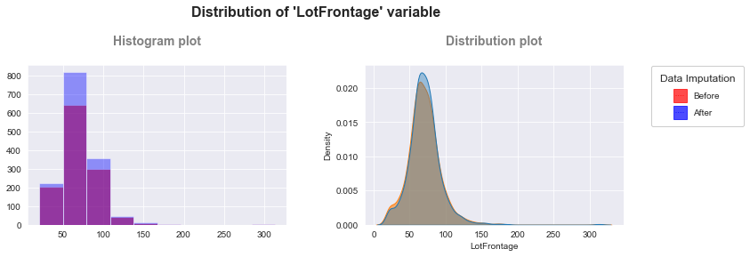

```python
plt.figure(figsize = [12, 4])
sb.set_style("darkgrid")

col = 'LotFrontage'
# subplot
plt.subplot(1, 2, 1)
plt.hist(df_temp[col], color='red', alpha = 0.6)
plt.hist(df_iter_imputed[col], color='blue', alpha = 0.4)
plt.title('Histogram plot'+ '\n', weight='bold', color='grey', fontsize=14)

# subplot
plt.subplot(1, 2, 2)
sb.distplot(df_temp[col], hist=False, kde = True,
            kde_kws = {'alpha' :0.6, "shade": True}, color = sb.color_palette()[1])
sb.distplot(df_iter_imputed[col], hist=False, kde = True,
            kde_kws = {'alpha' :0.4, "shade": True}, color = sb.color_palette()[0]);
plt.title('Distribution plot'+ '\n', weight='bold', color='grey', fontsize=14)

plt.suptitle(f"Distribution of '{col}' variable", fontsize = 16, weight = 'bold')
plt.subplots_adjust(top=0.75)
plt.subplots_adjust(wspace=0.3, hspace=0.3);

# add custom legend
# -------------------------------------------------------
custom_lines = [Line2D([0], [0], marker='s', markersize=15, color='red', linestyle=':', linewidth = 1, alpha=  0.7),
                Line2D([0], [0], marker='s', markersize=15, color='blue', linestyle=':', linewidth = 1, alpha=  0.7)]

legend1= plt.legend(custom_lines, ['Before', 'After'], scatterpoints=1, frameon=True, fancybox=True, shadow=False,
           ncol = 1, framealpha = 1, borderpad=1, borderaxespad=1, loc = 'upper right', labelspacing=1,
           title='Data Imputation', title_fontsize=12, fontsize=10, facecolor='white',
           markerfirst=True, handlelength=1, handletextpad=1, bbox_to_anchor=(1.5, 1.05));
# -------------------------------------------------------'
```

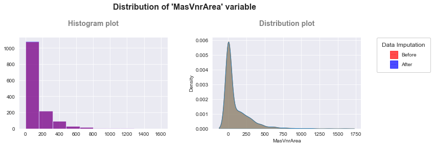

```python
plt.figure(figsize = [12, 4])
sb.set_style("darkgrid")

col = 'MasVnrArea'
# subplot
plt.subplot(1, 2, 1)
plt.hist(df_temp[col], color='red', alpha = 0.6)
plt.hist(df_iter_imputed[col], color='blue', alpha = 0.4)
plt.title('Histogram plot'+ '\n', weight='bold', color='grey', fontsize=14)

# subplot
plt.subplot(1, 2, 2)
sb.distplot(df_temp[col], hist=False, kde = True,
            kde_kws = {'alpha' :0.6, "shade": True}, color = sb.color_palette()[1])
sb.distplot(df_iter_imputed[col], hist=False, kde = True,
            kde_kws = {'alpha' :0.4, "shade": True}, color = sb.color_palette()[0]);
plt.title('Distribution plot'+ '\n', weight='bold', color='grey', fontsize=14)

plt.suptitle(f"Distribution of '{col}' variable", fontsize = 16, weight = 'bold')
plt.subplots_adjust(top=0.75)
plt.subplots_adjust(wspace=0.3, hspace=0.3);

# add custom legend
# -------------------------------------------------------
custom_lines = [Line2D([0], [0], marker='s', markersize=15, color='red', linestyle=':', linewidth = 1, alpha=  0.7),
                Line2D([0], [0], marker='s', markersize=15, color='blue', linestyle=':', linewidth = 1, alpha=  0.7)]

legend1= plt.legend(custom_lines, ['Before', 'After'], scatterpoints=1, frameon=True, fancybox=True, shadow=False,
           ncol = 1, framealpha = 1, borderpad=1, borderaxespad=1, loc = 'upper right', labelspacing=1,
           title='Data Imputation', title_fontsize=12, fontsize=10, facecolor='white',
           markerfirst=True, handlelength=1, handletextpad=1, bbox_to_anchor=(1.5, 1.05));
# -------------------------------------------------------'
```

It is evident from the above plots that the distribution of the data is not altered much from imputing the data. Hence enforcing data imputation for null values in source data.

```python
numerical_cols = []
for col in df.columns:
    if df[col].dtype == 'int64':
        numerical_cols.append(col)

print(numerical_cols)
```

```
['Id', 'MSSubClass', 'LotArea', 'OverallQual', 'OverallCond', 'YearBuilt', 'YearRemodAdd', 'BsmtFinSF1', 'BsmtFinSF2', 'BsmtUnfSF', 'TotalBsmtSF', '1stFlrSF', '2ndFlrSF', 'LowQualFinSF', 'GrLivArea', 'BsmtFullBath', 'BsmtHalfBath', 'FullBath', 'HalfBath', 'BedroomAbvGr', 'KitchenAbvGr', 'TotRmsAbvGr…
```

```python
# replace the columns having nulls with imputed columns
df['LotFrontage'] = df_iter_imputed['LotFrontage']
df['MasVnrArea'] = df_iter_imputed['MasVnrArea']
```

Check for null values in the modified dataset:

```python
# filter variables with null_count greater than zero, sort them by descending order
assess_df = programmatic_assessment(df)
null_count_df = assess_df[['variable',
                           'datatype',
                           'null_count',
                           'null_pcnt']][assess_df['null_count']>0].sort_values(by=['null_count'],
                                                                                ascending=False)

# import 'description' variable from 'info_df' dataframe
null_count_df['null_pcnt'] = null_count_df['null_pcnt'].apply(lambda x: float('{:0.2f}'.format(x)))

# highlight the null count in red color if the percentage of null_count is greater than 10% and fade otherwise in grey color
null_count_df.style.apply(lambda row: np.repeat('color: gray'
                                                    if row['null_pcnt'] < 25
                                                    else
                                                'color: red; background-color: lightyellow',
                                                row.shape[0]),
                          axis=1)
```

|  | variable | datatype | null_count | null_pcnt |
| --- | --- | --- | --- | --- |
| 57 | GarageType | object | 81.000000 | 5.500000 |
| 58 | GarageYrBlt | float64 | 81.000000 | 5.500000 |
| 59 | GarageFinish | object | 81.000000 | 5.500000 |
| 62 | GarageQual | object | 81.000000 | 5.500000 |
| 63 | GarageCond | object | 81.000000 | 5.500000 |
| 31 | BsmtExposure | object | 38.000000 | 2.600000 |
| 34 | BsmtFinType2 | object | 38.000000 | 2.600000 |
| 29 | BsmtQual | object | 37.000000 | 2.500000 |
| 30 | BsmtCond | object | 37.000000 | 2.500000 |
| 32 | BsmtFinType1 | object | 37.000000 | 2.500000 |
| 24 | MasVnrType | object | 8.000000 | 0.500000 |
| 41 | Electrical | object | 1.000000 | 0.100000 |

Understand the garage variables and its relation among them:

```python
garage_col_list = ['GarageType', 'GarageYrBlt', 'GarageFinish', 'GarageCars', 'GarageArea', 'GarageQual', 'GarageCond']
```

```python
mask = df['GarageType'].isna()
df[mask][garage_col_list]
```

|  | GarageType | GarageYrBlt | GarageFinish | GarageCars | GarageArea | GarageQual | GarageCond |
| --- | --- | --- | --- | --- | --- | --- | --- |
| 39 | NaN | NaN | NaN | 0 | 0 | NaN | NaN |
| 48 | NaN | NaN | NaN | 0 | 0 | NaN | NaN |
| 78 | NaN | NaN | NaN | 0 | 0 | NaN | NaN |
| 88 | NaN | NaN | NaN | 0 | 0 | NaN | NaN |
| 89 | NaN | NaN | NaN | 0 | 0 | NaN | NaN |
| ... | ... | ... | ... | ... | ... | ... | ... |
| 1349 | NaN | NaN | NaN | 0 | 0 | NaN | NaN |
| 1407 | NaN | NaN | NaN | 0 | 0 | NaN | NaN |
| 1449 | NaN | NaN | NaN | 0 | 0 | NaN | NaN |
| 1450 | NaN | NaN | NaN | 0 | 0 | NaN | NaN |
| 1453 | NaN | NaN | NaN | 0 | 0 | NaN | NaN |

81 rows × 7 columns

As the relevant entries has garage built year (`GarageYrBlt`) associated to null values in specified columns, the values can be categorized as `NA` (no garage) and `GarageYrBlt` as null values only (will be dealt in the further analysis).

```python
mask = df['GarageYrBlt'].isna()
df.loc[mask, 'GarageType'] = 'NA'
df.loc[mask, 'GarageFinish'] = 'NA'
df.loc[mask, 'GarageQual'] = 'NA'
df.loc[mask, 'GarageCond'] = 'NA'
```

Since we have no information related to Basement variable and removing these from the further analysis will only pertain to small data loss, they are dropped from the dataset.

```python
data_loss = round(((df['BsmtExposure'].isna().sum() / df.shape[0]) * 100), 1)
print(f"The data loss from dropping 'BsmtExposure' null entries is: '{data_loss}%'")
```

```
The data loss from dropping 'BsmtExposure' null entries is: '2.6%'
```

Since the remaining columns has low null value count, they can be removed from the further analysis without much data loss.

```python
# drop the null entries from above specified column list
col_list = ['BsmtExposure','BsmtFinType2','BsmtQual',
            'BsmtCond','BsmtFinType1','MasVnrType','Electrical']

for col in col_list:
    drop_index = df[df[col].isna()].index
    df = df.drop(drop_index)
```

Check for duplicate values in the dataset

```python
mask = df.duplicated()
df[mask]
```

|  | Id | MSSubClass | MSZoning | LotFrontage | LotArea | Street | LotShape | LandContour | Utilities | LotConfig | ... | EnclosedPorch | 3SsnPorch | ScreenPorch | PoolArea | MiscVal | MoSold | YrSold | SaleType | SaleCondition | SalePrice |
| --- | --- | --- | --- | --- | --- | --- | --- | --- | --- | --- | --- | --- | --- | --- | --- | --- | --- | --- | --- | --- | --- |

0 rows × 77 columns

No duplicates found

### Data Quality Check:

`MSZoning` column:

```python
df['MSZoning'].value_counts()
```

```
RL         1111
RM          214
FV           62
RH           15
C (all)      10
Name: MSZoning, dtype: int64
```

In the above variable, the category `C` is misspelled as `C (all)`. Retify/ rename it to appropriate value.

```python
mask = df['MSZoning'] == 'C (all)'
df.loc[mask, 'MSZoning'] = 'C'
```

### Feature Extraction:

Extract numerical information from the date variables: (Pay attention to `null values` in `GarageYrBlt` variable)

```python
year_cols = ['YearBuilt', 'YearRemodAdd', 'YrSold', 'MoSold', 'GarageYrBlt']
year_cols
```

```
['YearBuilt', 'YearRemodAdd', 'YrSold', 'MoSold', 'GarageYrBlt']
```

```python
df[year_cols]
```

|  | YearBuilt | YearRemodAdd | YrSold | MoSold | GarageYrBlt |
| --- | --- | --- | --- | --- | --- |
| 0 | 2003 | 2003 | 2008 | 2 | 2003.0 |
| 1 | 1976 | 1976 | 2007 | 5 | 1976.0 |
| 2 | 2001 | 2002 | 2008 | 9 | 2001.0 |
| 3 | 1915 | 1970 | 2006 | 2 | 1998.0 |
| 4 | 2000 | 2000 | 2008 | 12 | 2000.0 |
| ... | ... | ... | ... | ... | ... |
| 1455 | 1999 | 2000 | 2007 | 8 | 1999.0 |
| 1456 | 1978 | 1988 | 2010 | 2 | 1978.0 |
| 1457 | 1941 | 2006 | 2010 | 5 | 1941.0 |
| 1458 | 1950 | 1996 | 2010 | 4 | 1950.0 |
| 1459 | 1965 | 1965 | 2008 | 6 | 1965.0 |

1412 rows × 5 columns

```python
# calculate the age of the house
# years = 'YrSold' - 'YearBuilt' and obtain months from 'MoSold'
df['house_age_years'] = (df['YrSold'] - df['YearBuilt']) + df['MoSold'].apply(lambda x: float(f'0.{x}') if len(str(x))==2 else float(f'0.0{x}'))
```

```python
# calculate the age of the house
# years = 'YrSold' - 'YearBuilt' and obtain months from 'MoSold'
df['house_remodel_age_years'] = (df['YrSold'] - df['YearRemodAdd']) + df['MoSold'].apply(lambda x: float(f'0.{x}') if len(str(x))==2 else float(f'0.0{x}'))
```

```python
# calculate the age of the house
# years = 'YrSold' - 'YearBuilt' and obtain months from 'MoSold'
# Pay attention to null values in the GarageYrBlt variable
df['garage_age_years'] = (df['YrSold'] - df['GarageYrBlt']) + df['MoSold'].apply(lambda x: float(f'0.{x}') if len(str(x))==2 else float(f'0.0{x}'))
```

Since we have null values in `GarageYrBlt` variable, they create outliers in the `garage_age_years` calculated filed. Hence replace the values in `garage_age_years` variables subjected to null values in `GarageYrBlt` variable:

```python
mask = df[df['GarageYrBlt'].isna()].index
df.loc[mask, 'garage_age_years'] = 0
```

Observe the extracted variables:

```python
year_cols = ['YearBuilt', 'YearRemodAdd', 'GarageYrBlt', 'YrSold', 'MoSold',
             'house_age_years', 'house_remodel_age_years', 'garage_age_years']
df[year_cols]
```

|  | YearBuilt | YearRemodAdd | GarageYrBlt | YrSold | MoSold | house_age_years | house_remodel_age_years | garage_age_years |
| --- | --- | --- | --- | --- | --- | --- | --- | --- |
| 0 | 2003 | 2003 | 2003.0 | 2008 | 2 | 5.02 | 5.02 | 5.02 |
| 1 | 1976 | 1976 | 1976.0 | 2007 | 5 | 31.05 | 31.05 | 31.05 |
| 2 | 2001 | 2002 | 2001.0 | 2008 | 9 | 7.09 | 6.09 | 7.09 |
| 3 | 1915 | 1970 | 1998.0 | 2006 | 2 | 91.02 | 36.02 | 8.02 |
| 4 | 2000 | 2000 | 2000.0 | 2008 | 12 | 8.12 | 8.12 | 8.12 |
| ... | ... | ... | ... | ... | ... | ... | ... | ... |
| 1455 | 1999 | 2000 | 1999.0 | 2007 | 8 | 8.08 | 7.08 | 8.08 |
| 1456 | 1978 | 1988 | 1978.0 | 2010 | 2 | 32.02 | 22.02 | 32.02 |
| 1457 | 1941 | 2006 | 1941.0 | 2010 | 5 | 69.05 | 4.05 | 69.05 |
| 1458 | 1950 | 1996 | 1950.0 | 2010 | 4 | 60.04 | 14.04 | 60.04 |
| 1459 | 1965 | 1965 | 1965.0 | 2008 | 6 | 43.06 | 43.06 | 43.06 |

1412 rows × 8 columns

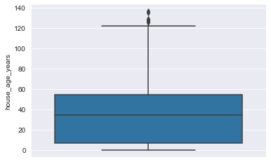

```python
sb.boxplot(y = df['house_age_years']);
```

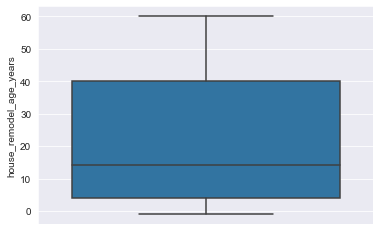

```python
sb.boxplot(y = df['house_remodel_age_years']);
```

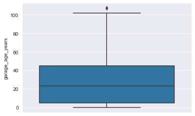

```python
sb.boxplot(y = df['garage_age_years']);
```

Drop the date variables as relevant information is extracted from them:

```python
drop_cols = ['YearBuilt', 'YearRemodAdd', 'GarageYrBlt', 'YrSold', 'MoSold']
df.drop(drop_cols, axis=1, inplace=True)
```

Confirm the drop of the columns:

```python
df.columns
```

```
Index(['Id', 'MSSubClass', 'MSZoning', 'LotFrontage', 'LotArea', 'Street',
       'LotShape', 'LandContour', 'Utilities', 'LotConfig', 'LandSlope',
       'Neighborhood', 'Condition1', 'Condition2', 'BldgType', 'HouseStyle',
       'OverallQual', 'OverallCond', 'RoofStyle', 'RoofMatl', 'Exterior1st',
       'Exterior2nd', 'MasVnrType', 'MasVnrArea', 'ExterQual', 'ExterCond',
       'Foundation', 'BsmtQual', 'BsmtCond', 'BsmtExposure', 'BsmtFinType1',
       'BsmtFinSF1', 'BsmtFinType2', 'BsmtFinSF2', 'BsmtUnfSF', 'TotalBsmtSF',
       'Heating', 'HeatingQC', 'CentralAir', 'Electrical', '1stFlrSF',
       '2ndFlrSF', 'LowQualFinSF', 'GrLivArea', 'BsmtFullBath', 'BsmtHalfBath',
       'FullBath', 'HalfBath', 'BedroomAbvGr', 'KitchenAbvGr', 'KitchenQual',
       'TotRmsAbvGrd', 'Functional', 'Fireplaces', 'FireplaceQu', 'GarageType',
       'GarageFinish', 'GarageCars', 'GarageArea', 'GarageQual', 'GarageCond',
       'PavedDrive', 'WoodDeckSF', 'OpenPorchSF', 'EnclosedPorch', '3SsnPorch',
       'ScreenPorch', 'PoolArea', 'MiscVal', 'SaleType', 'SaleCondition',
       'SalePrice', 'house_age_years', 'house_remodel_age_years',
       'garage_age_years'],
      dtype='object')
```

Confirm there are no null values in the dataset:

```python
df.isna().sum().sum()
```

```
0
```

### Check the variables with low variance:

Identify low disperse data:

```python
# identify low disperse data
low_var_cols = []
for col in df.columns:
    if len(df[col].value_counts().index) < 3:
        low_var_cols.append(col)

print(low_var_cols)
```

```
['Street', 'Utilities', 'CentralAir']
```

```python
df.Street.value_counts()
```

```
Pave    1406
Grvl       6
Name: Street, dtype: int64
```

```python
df.Utilities.value_counts()
```

```
AllPub    1411
NoSeWa       1
Name: Utilities, dtype: int64
```

```python
df.CentralAir.value_counts()
```

```
Y    1331
N      81
Name: CentralAir, dtype: int64
```

As these variables has low variance, remove them from further analysis.

```python
drop_cols = ['Street', 'Utilities', 'CentralAir']
df.drop(drop_cols, axis=1, inplace=True)
```

As `Id` column is redundant in the further analysis, remove it.

```python
drop_cols = ['Id']
df.drop(drop_cols, axis=1, inplace=True)
```

As `GarageCars` potray the same information as `GarageArea` but in different metric, it can be dropped from the analysis.

```python
drop_cols = ['GarageCars']
df.drop(drop_cols, axis=1, inplace=True)
```

### Outlier Treatment:

```python
df_temp = df.copy(deep=True)
```

```python
def remove_outliers(df):
    numerical_cols = [col for col in df.columns if df[col].dtype != 'O']
    for col in numerical_cols:
        Q1 = df[col].quantile(.25)
        Q3 = df[col].quantile(.99)
        IQR = Q3-Q1
        mask = (df[col]>=(Q1-(1.5*IQR))) & (df[col]<=(Q3+(1.5*IQR)))
        df =  df[mask]
    return df


df_temp = remove_outliers(df_temp)
```

```python
df_temp.shape
```

```
(1392, 70)
```

```python
df.shape
```

```
(1412, 70)
```

Calculate for the data loss in case of outlier removal:

```python
print(f'Data loss would be: {round((((df.shape[0] - df_temp.shape[0])/df.shape[0])*100), 1)}%')
```

```
Data loss would be: 1.4%
```

```python
def remove_outliers(df):
    numerical_cols = [col for col in df.columns if df[col].dtype != 'O']
    for col in numerical_cols:
        Q1 = df[col].quantile(.25)
        Q3 = df[col].quantile(.99)
        IQR = Q3-Q1
        mask = (df[col]>=(Q1-(1.5*IQR))) & (df[col]<=(Q3+(1.5*IQR)))
        df =  df[mask]
    return df


df = remove_outliers(df)
```

### Categorical data imputation:

```python
categorical_cols = [col for col in df.columns if df[col].dtype == 'O']
print(categorical_cols)
```

```
['MSZoning', 'LotShape', 'LandContour', 'LotConfig', 'LandSlope', 'Neighborhood', 'Condition1', 'Condition2', 'BldgType', 'HouseStyle', 'RoofStyle', 'RoofMatl', 'Exterior1st', 'Exterior2nd', 'MasVnrType', 'ExterQual', 'ExterCond', 'Foundation', 'BsmtQual', 'BsmtCond', 'BsmtExposure', 'BsmtFinType1',…
```

As per the data dictionry, below are the ordinal categorical variables:

```python
df[['LandSlope','ExterQual','BsmtQual','BsmtCond','BsmtExposure',
    'BsmtFinType1','BsmtFinType2','HeatingQC','KitchenQual',
    'GarageFinish','GarageQual','GarageCond','ExterCond','LotShape']].head()
```

|  | LandSlope | ExterQual | BsmtQual | BsmtCond | BsmtExposure | BsmtFinType1 | BsmtFinType2 | HeatingQC | KitchenQual | GarageFinish | GarageQual | GarageCond | ExterCond | LotShape |
| --- | --- | --- | --- | --- | --- | --- | --- | --- | --- | --- | --- | --- | --- | --- |
| 0 | Gtl | Gd | Gd | TA | No | GLQ | Unf | Ex | Gd | RFn | TA | TA | TA | Reg |
| 1 | Gtl | TA | Gd | TA | Gd | ALQ | Unf | Ex | TA | RFn | TA | TA | TA | Reg |
| 2 | Gtl | Gd | Gd | TA | Mn | GLQ | Unf | Ex | Gd | RFn | TA | TA | TA | IR1 |
| 3 | Gtl | TA | TA | Gd | No | ALQ | Unf | Gd | Gd | Unf | TA | TA | TA | IR1 |
| 4 | Gtl | Gd | Gd | TA | Av | GLQ | Unf | Ex | Gd | RFn | TA | TA | TA | IR1 |

Impute the categorical data as per order:

```python
df['ExterQual'].unique()
```

```
array(['Gd', 'TA', 'Ex', 'Fa'], dtype=object)
```

```python
df['LandSlope'] = df.LandSlope.map({'Gtl':0,'Mod':1,'Sev':2})
df['ExterQual'] = df.ExterQual.map({'Po':0,'Fa':1,'TA':2,'Gd':3,'Ex':4})
df['BsmtQual'] = df.BsmtQual.map({'NA':0,'Po':1,'Fa':2,'TA':3,'Gd':4,'Ex':5})
df['BsmtCond'] = df.BsmtCond.map({'NA':0,'Po':1,'Fa':2,'TA':3,'Gd':4,'Ex':5})
df['BsmtExposure'] = df.BsmtExposure.map({'NA':0,'No':1,'Mn':2,'Av':3,'Gd':4})
df['BsmtFinType1'] = df.BsmtFinType1.map({'NA':0,'Unf':1,'LwQ':2,'Rec':3,'BLQ':4,'ALQ':5,'GLQ':6})
df['BsmtFinType2'] = df.BsmtFinType2.map({'NA':0,'Unf':1,'LwQ':2,'Rec':3,'BLQ':4,'ALQ':5,'GLQ':6})
df['HeatingQC'] = df.HeatingQC.map({'Po':0,'Fa':1,'TA':2,'Gd':3,'Ex':4})
df['KitchenQual'] = df.KitchenQual.map({'Po':0,'Fa':1,'TA':2,'Gd':3,'Ex':4})
df['GarageFinish'] = df.GarageFinish.map({'NA':0,'Unf':1,'RFn':2,'Fin':3})
df['GarageQual'] = df.GarageQual.map({'NA':0,'Po':1,'Fa':2,'TA':3,'Gd':4,'Ex':5})
df['GarageCond'] = df.GarageCond.map({'NA':0,'Po':1,'Fa':2,'TA':3,'Gd':4,'Ex':5})
df['ExterCond'] = df.ExterCond.map({'Po':0,'Fa':1,'TA':2,'Gd':3,'Ex':4})
df['LotShape'] = df.LotShape.map({'IR1':0,'IR2':1,'IR3':2,'Reg':3})
```

```python
df[['LandSlope','ExterQual','BsmtQual','BsmtCond','BsmtExposure',
    'BsmtFinType1','BsmtFinType2','HeatingQC','KitchenQual',
    'GarageFinish','GarageQual','GarageCond','ExterCond','LotShape']].head()
```

|  | LandSlope | ExterQual | BsmtQual | BsmtCond | BsmtExposure | BsmtFinType1 | BsmtFinType2 | HeatingQC | KitchenQual | GarageFinish | GarageQual | GarageCond | ExterCond | LotShape |
| --- | --- | --- | --- | --- | --- | --- | --- | --- | --- | --- | --- | --- | --- | --- |
| 0 | 0 | 3 | 4 | 3 | 1 | 6 | 1 | 4 | 3 | 2 | 3 | 3 | 2 | 3 |
| 1 | 0 | 2 | 4 | 3 | 4 | 5 | 1 | 4 | 2 | 2 | 3 | 3 | 2 | 3 |
| 2 | 0 | 3 | 4 | 3 | 2 | 6 | 1 | 4 | 3 | 2 | 3 | 3 | 2 | 0 |
| 3 | 0 | 2 | 3 | 4 | 1 | 5 | 1 | 3 | 3 | 1 | 3 | 3 | 2 | 0 |
| 4 | 0 | 3 | 4 | 3 | 3 | 6 | 1 | 4 | 3 | 2 | 3 | 3 | 2 | 0 |

```python
df[['LandSlope','ExterQual','BsmtQual','BsmtCond','BsmtExposure',
    'BsmtFinType1','BsmtFinType2','HeatingQC','KitchenQual',
    'GarageFinish','GarageQual','GarageCond','ExterCond','LotShape']].dtypes
```

```
LandSlope       int64
ExterQual       int64
BsmtQual        int64
BsmtCond        int64
BsmtExposure    int64
BsmtFinType1    int64
BsmtFinType2    int64
HeatingQC       int64
KitchenQual     int64
GarageFinish    int64
GarageQual      int64
GarageCond      int64
ExterCond       int64
LotShape        int64
dtype: object
```

### Exploratory data analysis:

Correlation plot:

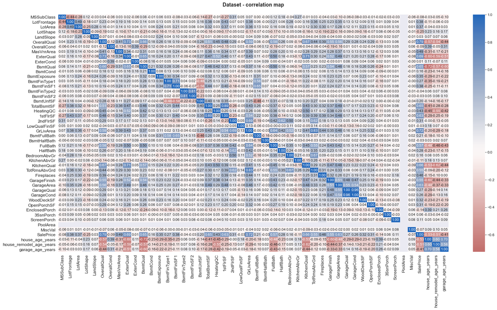

```python
df_corr = df.corr()

# correlation plot
plt.figure(figsize = [24, 12])
sb.heatmap(df_corr, annot = True, fmt = '.2f', cmap = 'vlag_r', center = 0)
plt.title('Dataset - correlation map\n', weight = 'bold', fontsize = 14)
plt.xticks(fontsize=12)
plt.yticks(fontsize=12);
```

Pair plot: (not executed because of high processing time)